# Final Project - Predicting PDAC with Circulating miRNA - Multi-miRNA and Consensus Feature Analysis

2026-04-23

# Multi-miRNA and Consensus Feature Analysis

This report loads the saved consensus-feature inputs written by the main PDAC modeling report and performs the downstream multiMiR and final consensus-feature summary analysis separately.

## Top-ranked Consensus miRNAs

Loaded downstream consensus-feature inputs from Data/Top-ranked consensus miRNA downstream inputs.rds. Top-rank selection count: 4 non-tree models.

Top-ranked consensus miRNAs from the non-tree models

| miRNA | Annotation | n_models_selected | limma_log_fc | limma_t | limma_p_value | limma_adj_p_value |
| --- | --- | --- | --- | --- | --- | --- |
| MIMAT0000063 | hsa-let-7b-5p | 4 | -0.1539616 | -3.481557 | 0.0005088 | 0.1012441 |

## Merged miRNA Set for Downstream multiMiR Queries

The downstream multiMiR query set contains 10 merged top miRNA features drawn from the consensus, decision-tree, and random-forest rankings.

Merged top miRNA features with derived multiMiR query identifiers

| miRNA | Annotation | multiMiR_query_id |
| --- | --- | --- |
| MIMAT0000063 | hsa-let-7b-5p | hsa-let-7b-5p |
| MIMAT0000687 | hsa-miR-299-3p | hsa-miR-299-3p |
| MIMAT0000261 | hsa-miR-183-5p | hsa-miR-183-5p |
| MIMAT0015050 | hsa-miR-323b-3p | hsa-miR-323b-3p |
| MIMAT0003161 | hsa-miR-493-3p | hsa-miR-493-3p |
| MIMAT0001545 | hsa-miR-450a-5p | hsa-miR-450a-5p |
| MIMAT0001631 | hsa-miR-451a | hsa-miR-451a |
| MIMAT0000427 | hsa-miR-133a-3p | hsa-miR-133a-3p |
| MIMAT0015020 | hsa-miR-548v | hsa-miR-548v |
| MIMAT0000273 | hsa-miR-216a-5p | hsa-miR-216a-5p |

## miRNA Interactions

Assess validated target and disease/drug associations for the merged top-ranked miRNA set with multiMiR.

multiMiR query miRNAs: hsa-let-7b-5p, hsa-miR-493-3p, hsa-miR-450a-5p, hsa-miR-451a, hsa-miR-133a-3p, hsa-miR-183-5p, hsa-miR-299-3p, hsa-miR-548v, hsa-miR-216a-5p, and hsa-miR-323b-3p

Validated multiMiR target-protein records for the merged top-feature miRNA set

| miRNA | Annotation | multiMiR_query_id | target_symbol | target_entrez | target_ensembl | database |
| --- | --- | --- | --- | --- | --- | --- |
| MIMAT0000063 | hsa-let-7b-5p | hsa-let-7b-5p | LIN28 |  | ENSG00000131914 | mirecords |
| MIMAT0000063 | hsa-let-7b-5p | hsa-let-7b-5p | CCND1 | 595 | ENSG00000110092 | mirecords |
| MIMAT0000063 | hsa-let-7b-5p | hsa-let-7b-5p | CDC25A | 993 | ENSG00000164045 | mirecords |
| MIMAT0000063 | hsa-let-7b-5p | hsa-let-7b-5p | BCL7A | 605 | ENSG00000110987 | mirecords |
| MIMAT0000063 | hsa-let-7b-5p | hsa-let-7b-5p | HMGA2 | 8091 | ENSG00000149948 | mirecords |
| MIMAT0000063 | hsa-let-7b-5p | hsa-let-7b-5p | HMGA2 | 8091 | ENSG00000149948 | mirecords |
| MIMAT0000063 | hsa-let-7b-5p | hsa-let-7b-5p | HMGA2 | 8091 | ENSG00000149948 | mirecords |
| MIMAT0000063 | hsa-let-7b-5p | hsa-let-7b-5p | HMGA2 | 8091 | ENSG00000149948 | mirecords |
| MIMAT0000063 | hsa-let-7b-5p | hsa-let-7b-5p | HMGA2 | 8091 | ENSG00000149948 | mirecords |
| MIMAT0000063 | hsa-let-7b-5p | hsa-let-7b-5p | HMGA2 | 8091 | ENSG00000149948 | mirecords |
| MIMAT0000063 | hsa-let-7b-5p | hsa-let-7b-5p | CDK6 | 1021 | ENSG00000105810 | mirecords |
| MIMAT0000063 | hsa-let-7b-5p | hsa-let-7b-5p | CDC25A | 993 | ENSG00000164045 | mirecords |
| MIMAT0000063 | hsa-let-7b-5p | hsa-let-7b-5p | CDC34 | 997 | ENSG00000099804 | mirecords |
| MIMAT0000063 | hsa-let-7b-5p | hsa-let-7b-5p | KRT |  |  | mirecords |
| MIMAT0000063 | hsa-let-7b-5p | hsa-let-7b-5p | HES1 | 3280 | ENSG00000114315 | mirtarbase |

Validated multiMiR interaction records across the merged top-feature miRNA set: 29866; unique target genes: 13090; queried miRNAs with validated targets: 10 of 10

Top validated multiMiR targets for the merged top-feature miRNA set

| miRNA | Annotation | multiMiR_query_id | n_models_selected | target_symbol | target_entrez | target_ensembl | validated_support | total_support |
| --- | --- | --- | --- | --- | --- | --- | --- | --- |
| MIMAT0000063 | hsa-let-7b-5p | hsa-let-7b-5p | 4 | BCL7A | 605 | ENSG00000110987 | 3 | 3 |
| MIMAT0000063 | hsa-let-7b-5p | hsa-let-7b-5p | 4 | CCND1 | 595 | ENSG00000110092 | 3 | 3 |
| MIMAT0000063 | hsa-let-7b-5p | hsa-let-7b-5p | 4 | CDC25A | 993 | ENSG00000164045 | 3 | 3 |
| MIMAT0000063 | hsa-let-7b-5p | hsa-let-7b-5p | 4 | CDC34 | 997 | ENSG00000099804 | 3 | 3 |
| MIMAT0000063 | hsa-let-7b-5p | hsa-let-7b-5p | 4 | CDK6 | 1021 | ENSG00000105810 | 3 | 3 |
| MIMAT0000063 | hsa-let-7b-5p | hsa-let-7b-5p | 4 | HMGA2 | 8091 | ENSG00000149948 | 3 | 3 |
| MIMAT0000063 | hsa-let-7b-5p | hsa-let-7b-5p | 4 | ABCB10 | 23456 | ENSG00000135776 | 2 | 2 |
| MIMAT0000063 | hsa-let-7b-5p | hsa-let-7b-5p | 4 | ABCB8 | 11194 | ENSG00000197150 | 2 | 2 |
| MIMAT0000063 | hsa-let-7b-5p | hsa-let-7b-5p | 4 | ABCF1 | 23 | ENSG00000204574 | 2 | 2 |
| MIMAT0000063 | hsa-let-7b-5p | hsa-let-7b-5p | 4 | ABHD17C | 58489 | ENSG00000136379 | 2 | 2 |
| MIMAT0000063 | hsa-let-7b-5p | hsa-let-7b-5p | 4 | ABL1 | 25 | ENSG00000097007 | 2 | 2 |
| MIMAT0000063 | hsa-let-7b-5p | hsa-let-7b-5p | 4 | ACACA | 31 | ENSG00000278540 | 2 | 2 |
| MIMAT0000063 | hsa-let-7b-5p | hsa-let-7b-5p | 4 | ACER2 | 340485 | ENSG00000177076 | 2 | 2 |
| MIMAT0000063 | hsa-let-7b-5p | hsa-let-7b-5p | 4 | ACOT9 | 23597 | ENSG00000123130 | 2 | 2 |
| MIMAT0000063 | hsa-let-7b-5p | hsa-let-7b-5p | 4 | ACP3 | 55 | ENSG00000014257 | 2 | 2 |

multiMiR disease/drug association records across the merged top-feature miRNA set: 260; unique association terms: 96; queried miRNAs with disease/drug associations: 8 of 10

Top multiMiR disease/drug associations for the merged top-feature miRNA set

| miRNA | Annotation | multiMiR_query_id | n_models_selected | disease_drug | n_records | n_databases | n_pubmed |
| --- | --- | --- | --- | --- | --- | --- | --- |
| MIMAT0000063 | hsa-let-7b-5p | hsa-let-7b-5p | 4 | Cancer | 4 | 1 | 4 |
| MIMAT0000063 | hsa-let-7b-5p | hsa-let-7b-5p | 4 | Hepatocellular carcinoma | 3 | 1 | 3 |
| MIMAT0000063 | hsa-let-7b-5p | hsa-let-7b-5p | 4 | Muscular | 3 | 1 | 3 |
| MIMAT0000063 | hsa-let-7b-5p | hsa-let-7b-5p | 4 | Ovarian cancer | 3 | 1 | 3 |
| MIMAT0000063 | hsa-let-7b-5p | hsa-let-7b-5p | 4 | Breast cancer | 2 | 1 | 2 |
| MIMAT0000063 | hsa-let-7b-5p | hsa-let-7b-5p | 4 | Cardiomyopathy, dilated | 2 | 1 | 2 |
| MIMAT0000063 | hsa-let-7b-5p | hsa-let-7b-5p | 4 | Colorectal cancer | 2 | 1 | 2 |
| MIMAT0000063 | hsa-let-7b-5p | hsa-let-7b-5p | 4 | Leukemia, acute myeloid | 2 | 1 | 2 |
| MIMAT0000063 | hsa-let-7b-5p | hsa-let-7b-5p | 4 | lung cancer | 2 | 1 | 2 |
| MIMAT0000063 | hsa-let-7b-5p | hsa-let-7b-5p | 4 | Lung cancer | 2 | 1 | 2 |
| MIMAT0000063 | hsa-let-7b-5p | hsa-let-7b-5p | 4 | Melanoma and neural system tumor syndrome | 2 | 1 | 2 |
| MIMAT0000063 | hsa-let-7b-5p | hsa-let-7b-5p | 4 | Neuroblastoma | 2 | 1 | 2 |
| MIMAT0000063 | hsa-let-7b-5p | hsa-let-7b-5p | 4 | Prostate cancer | 2 | 1 | 2 |
| MIMAT0000063 | hsa-let-7b-5p | hsa-let-7b-5p | 4 | acute lymphoblastic leukemia (ALL) | 1 | 1 | 1 |
| MIMAT0000063 | hsa-let-7b-5p | hsa-let-7b-5p | 4 | acute myeloid leukemia (AML) | 1 | 1 | 1 |

## Shared Validated multiMiR Target Genes

Summarize validated target genes across the saved multiMiR results object for the merged top-feature miRNA set.

Loaded saved multiMiR results from Data/Top-ranked consensus miRNA multiMiR results.rds and summarized 13090 validated target genes across 10 queried merged top-feature miRNAs.

Validated target genes shared across the merged top-feature miRNA set

| target_symbol | target_entrez | target_ensembl | n_consensus_miRNA | consensus_miRNA | total_validated_support | total_support | max_models_selected |
| --- | --- | --- | --- | --- | --- | --- | --- |
| ZZZ3 | 26009 | ENSG00000036549 | 8 | hsa-let-7b-5p, hsa-miR-133a-3p, hsa-miR-183-5p, hsa-miR-216a-5p, hsa-miR-299-3p, hsa-miR-323b-3p, hsa-miR-451a, and hsa-miR-548v | 9 | 9 | 4 |
| MAP1B | 4131 | ENSG00000131711 | 8 | hsa-let-7b-5p, hsa-miR-133a-3p, hsa-miR-183-5p, hsa-miR-216a-5p, hsa-miR-299-3p, hsa-miR-450a-5p, hsa-miR-451a, and hsa-miR-493-3p | 8 | 8 | 4 |
| CCND1 | 595 | ENSG00000110092 | 7 | hsa-let-7b-5p, hsa-miR-133a-3p, hsa-miR-183-5p, hsa-miR-323b-3p, hsa-miR-450a-5p, hsa-miR-451a, and hsa-miR-493-3p | 10 | 10 | 4 |
| CLTC | 1213 | ENSG00000141367 | 7 | hsa-let-7b-5p, hsa-miR-133a-3p, hsa-miR-183-5p, hsa-miR-299-3p, hsa-miR-450a-5p, hsa-miR-451a, and hsa-miR-493-3p | 7 | 7 | 4 |
| FN1 | 2335 | ENSG00000115414 | 7 | hsa-let-7b-5p, hsa-miR-133a-3p, hsa-miR-183-5p, hsa-miR-323b-3p, hsa-miR-450a-5p, hsa-miR-451a, and hsa-miR-493-3p | 7 | 7 | 4 |
| SPTBN1 | 6711 | ENSG00000115306 | 7 | hsa-let-7b-5p, hsa-miR-183-5p, hsa-miR-299-3p, hsa-miR-323b-3p, hsa-miR-450a-5p, hsa-miR-451a, and hsa-miR-493-3p | 7 | 7 | 4 |
| TTN | 7273 | ENSG00000155657 | 7 | hsa-let-7b-5p, hsa-miR-133a-3p, hsa-miR-183-5p, hsa-miR-323b-3p, hsa-miR-450a-5p, hsa-miR-451a, and hsa-miR-493-3p | 7 | 7 | 4 |
| FSCN1 | 6624 | ENSG00000075618 | 6 | hsa-let-7b-5p, hsa-miR-133a-3p, hsa-miR-183-5p, hsa-miR-299-3p, hsa-miR-450a-5p, and hsa-miR-493-3p | 8 | 8 | 4 |
| BAZ1B | 9031 | ENSG00000009954 | 6 | hsa-let-7b-5p, hsa-miR-133a-3p, hsa-miR-183-5p, hsa-miR-299-3p, hsa-miR-450a-5p, and hsa-miR-493-3p | 7 | 7 | 4 |
| CHD4 | 1108 | ENSG00000111642 | 6 | hsa-let-7b-5p, hsa-miR-133a-3p, hsa-miR-183-5p, hsa-miR-450a-5p, hsa-miR-451a, and hsa-miR-493-3p | 7 | 7 | 4 |
| DYNC1H1 | 1778 | ENSG00000197102 | 6 | hsa-let-7b-5p, hsa-miR-183-5p, hsa-miR-299-3p, hsa-miR-450a-5p, hsa-miR-451a, and hsa-miR-493-3p | 7 | 7 | 4 |
| HIF1A | 3091 | ENSG00000100644 | 6 | hsa-let-7b-5p, hsa-miR-133a-3p, hsa-miR-183-5p, hsa-miR-299-3p, hsa-miR-450a-5p, and hsa-miR-493-3p | 7 | 7 | 4 |
| TLN1 | 7094 | ENSG00000137076 | 6 | hsa-let-7b-5p, hsa-miR-133a-3p, hsa-miR-183-5p, hsa-miR-299-3p, hsa-miR-450a-5p, and hsa-miR-493-3p | 7 | 7 | 4 |
| ZBTB37 | 84614 | ENSG00000185278 | 6 | hsa-let-7b-5p, hsa-miR-133a-3p, hsa-miR-183-5p, hsa-miR-450a-5p, hsa-miR-493-3p, and hsa-miR-548v | 7 | 7 | 4 |
| ANKRD50 | 57182 | ENSG00000151458 | 6 | hsa-let-7b-5p, hsa-miR-133a-3p, hsa-miR-183-5p, hsa-miR-450a-5p, hsa-miR-451a, and hsa-miR-548v | 6 | 6 | 4 |
| ATP2B1 | 490 | ENSG00000070961 | 6 | hsa-let-7b-5p, hsa-miR-133a-3p, hsa-miR-183-5p, hsa-miR-299-3p, hsa-miR-451a, and hsa-miR-493-3p | 6 | 6 | 4 |
| HELZ | 9931 | ENSG00000198265 | 6 | hsa-let-7b-5p, hsa-miR-133a-3p, hsa-miR-183-5p, hsa-miR-323b-3p, hsa-miR-450a-5p, and hsa-miR-451a | 6 | 6 | 4 |
| KMT2A | 4297 | ENSG00000118058 | 6 | hsa-let-7b-5p, hsa-miR-133a-3p, hsa-miR-183-5p, hsa-miR-216a-5p, hsa-miR-450a-5p, and hsa-miR-493-3p | 6 | 6 | 4 |
| MBNL1 | 4154 | ENSG00000152601 | 6 | hsa-let-7b-5p, hsa-miR-183-5p, hsa-miR-323b-3p, hsa-miR-450a-5p, hsa-miR-451a, and hsa-miR-548v | 6 | 6 | 4 |
| MYH9 | 4627 | ENSG00000100345 | 6 | hsa-let-7b-5p, hsa-miR-133a-3p, hsa-miR-183-5p, hsa-miR-299-3p, hsa-miR-450a-5p, and hsa-miR-493-3p | 6 | 6 | 4 |

## GO Terms for Validated multiMiR Target Proteins

Use the validated multiMiR target-protein set to run GO biological-process enrichment, following the same downstream biology emphasis as your teammate’s selected analysis.

GO biological-process enrichment for validated multiMiR target proteins

| ID | Description | GeneRatio | BgRatio | RichFactor | FoldEnrichment | zScore | pvalue | p.adjust | qvalue | geneID | Count |
| --- | --- | --- | --- | --- | --- | --- | --- | --- | --- | --- | --- |
| GO:0010975 | regulation of neuron projection development | 402/12010 | 448/18860 | 0.897 | 1.409 | 11.604 | 0 | 0 | 0 | 3280/5587/5058/2146/1399/25/655/1523/1756/2033/2043/2803/347…… | 402 |
| GO:0016236 | macroautophagy | 363/12010 | 403/18860 | 0.901 | 1.414 | 11.137 | 0 | 0 | 0 | 3091/9146/665/488/535/550/1457/2033/2597/3064/4734/5563/5899…… | 363 |
| GO:0051052 | regulation of DNA metabolic process | 431/12010 | 497/18860 | 0.867 | 1.362 | 10.824 | 0 | 0 | 0 | 993/605/8091/1026/1027/4609/3146/11177/25/9212/890/5347/2324…… | 431 |
| GO:0072657 | protein localization to membrane | 397/12010 | 458/18860 | 0.867 | 1.361 | 10.362 | 0 | 0 | 0 | 9341/391/1399/9146/208/5962/65125/23136/60/367/975/2316/2803…… | 397 |
| GO:0048193 | Golgi vesicle transport | 288/12010 | 319/18860 | 0.903 | 1.418 | 9.964 | 0 | 0 | 0 | 9341/5587/372/738/1453/1523/2803/3064/7109/8452/8615/8729/87…… | 288 |
| GO:0050803 | regulation of synapse structure or activity | 294/12010 | 329/18860 | 0.894 | 1.403 | 9.771 | 0 | 0 | 0 | 391/25/7534/27161/388/7097/1108/2043/4208/4734/7779/9040/101…… | 294 |
| GO:0060560 | developmental growth involved in morphogenesis | 227/12010 | 246/18860 | 0.923 | 1.449 | 9.387 | 0 | 0 | 0 | 157506/5058/25/10413/1906/2803/3475/6662/6790/6857/7414/8936…… | 227 |
| GO:0042176 | regulation of protein catabolic process | 330/12010 | 383/18860 | 0.862 | 1.353 | 9.243 | 0 | 0 | 0 | 1027/9709/9146/3949/5347/5962/975/1453/1457/1915/2316/3304/3…… | 330 |
| GO:0016055 | Wnt signaling pathway | 408/12010 | 487/18860 | 0.838 | 1.316 | 9.344 | 0 | 0 | 0 | 595/8091/4772/4609/6789/25/10413/7097/65125/1453/1457/1857/1…… | 408 |
| GO:0140694 | membraneless organelle assembly | 374/12010 | 446/18860 | 0.839 | 1.317 | 8.967 | 0 | 0 | 0 | 8243/5587/3796/9212/27161/5347/65125/58/332/367/550/1453/145…… | 374 |
| GO:0000209 | protein polyubiquitination | 261/12010 | 300/18860 | 0.870 | 1.366 | 8.466 | 0 | 0 | 0 | 997/117584/55585/865/4734/5563/7174/7322/7323/8452/8454/9320…… | 261 |
| GO:0031669 | cellular response to nutrient levels | 244/12010 | 282/18860 | 0.865 | 1.359 | 8.037 | 0 | 0 | 0 | 8202/5587/1026/6667/5058/7534/632/2033/4023/5366/5563/5594/6…… | 244 |
| GO:0060562 | epithelial tube morphogenesis | 289/12010 | 344/18860 | 0.840 | 1.319 | 7.913 | 0 | 0 | 0 | 8091/3280/157506/3845/4609/6789/5058/3091/25/655/10413/388/9…… | 289 |
| GO:0022613 | ribonucleoprotein complex biogenesis | 399/12010 | 496/18860 | 0.804 | 1.263 | 7.867 | 0 | 0 | 0 | 23405/26523/27161/192669/5036/1662/3320/3921/4931/8161/8602/…… | 399 |
| GO:0051402 | neuron apoptotic process | 268/12010 | 318/18860 | 0.843 | 1.323 | 7.702 | 0 | 0 | 0 | 595/3845/7832/3091/25/208/2043/2597/4208/10280/10891/23129/2…… | 268 |

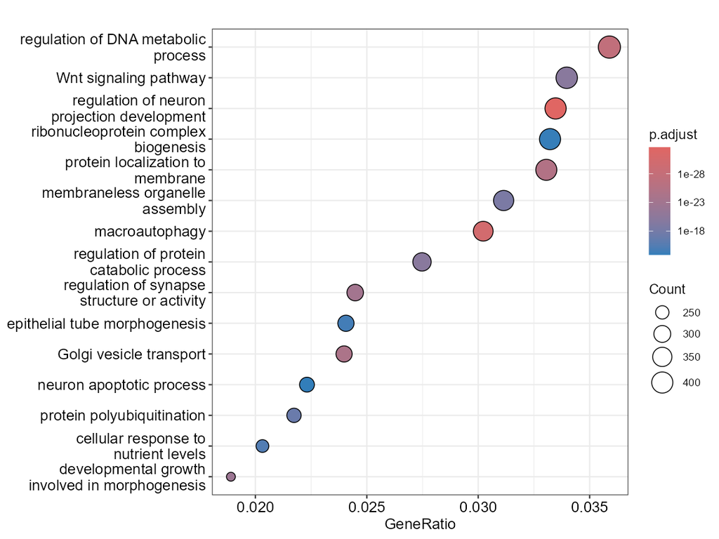

## Shared multiMiR Disease/Drug Terms

Summarize disease/drug terms across the saved multiMiR results object for the merged top-feature miRNA set.

Loaded saved multiMiR results from Data/Top-ranked consensus miRNA multiMiR results.rds and summarized 96 disease/drug terms across 10 queried merged top-feature miRNAs.

Disease/drug terms shared across the merged top-feature miRNA set

| disease_drug | n_consensus_miRNA | consensus_miRNA | total_records | total_databases | total_pubmed | max_models_selected |
| --- | --- | --- | --- | --- | --- | --- |
| Ovarian cancer | 7 | hsa-let-7b-5p, hsa-miR-133a-3p, hsa-miR-183-5p, hsa-miR-216a-5p, hsa-miR-299-3p, hsa-miR-451a, and hsa-miR-493-3p | 13 | 7 | 13 | 4 |
| Breast cancer | 7 | hsa-let-7b-5p, hsa-miR-133a-3p, hsa-miR-183-5p, hsa-miR-216a-5p, hsa-miR-299-3p, hsa-miR-451a, and hsa-miR-493-3p | 10 | 7 | 10 | 4 |
| Lung cancer | 6 | hsa-let-7b-5p, hsa-miR-133a-3p, hsa-miR-183-5p, hsa-miR-216a-5p, hsa-miR-299-3p, and hsa-miR-451a | 12 | 6 | 12 | 4 |
| Melanoma and neural system tumor syndrome | 6 | hsa-let-7b-5p, hsa-miR-133a-3p, hsa-miR-183-5p, hsa-miR-216a-5p, hsa-miR-299-3p, and hsa-miR-493-3p | 9 | 6 | 9 | 4 |
| Leukemia, acute myeloid | 6 | hsa-let-7b-5p, hsa-miR-133a-3p, hsa-miR-299-3p, hsa-miR-450a-5p, hsa-miR-451a, and hsa-miR-493-3p | 8 | 6 | 8 | 4 |
| Hematological | 6 | hsa-let-7b-5p, hsa-miR-133a-3p, hsa-miR-183-5p, hsa-miR-216a-5p, hsa-miR-299-3p, and hsa-miR-451a | 6 | 6 | 6 | 4 |
| Cancer | 5 | hsa-let-7b-5p, hsa-miR-133a-3p, hsa-miR-183-5p, hsa-miR-299-3p, and hsa-miR-450a-5p | 10 | 5 | 10 | 4 |
| Colorectal cancer | 5 | hsa-let-7b-5p, hsa-miR-133a-3p, hsa-miR-183-5p, hsa-miR-216a-5p, and hsa-miR-299-3p | 9 | 5 | 9 | 4 |
| Squamous cell carcinoma, head and neck | 5 | hsa-let-7b-5p, hsa-miR-133a-3p, hsa-miR-183-5p, hsa-miR-216a-5p, and hsa-miR-299-3p | 8 | 5 | 8 | 4 |
| Muscular | 5 | hsa-let-7b-5p, hsa-miR-133a-3p, hsa-miR-299-3p, hsa-miR-451a, and hsa-miR-493-3p | 7 | 5 | 7 | 4 |
| Pancreatic cancer | 5 | hsa-let-7b-5p, hsa-miR-133a-3p, hsa-miR-183-5p, hsa-miR-216a-5p, and hsa-miR-299-3p | 7 | 5 | 7 | 4 |
| Prostate cancer | 5 | hsa-let-7b-5p, hsa-miR-133a-3p, hsa-miR-183-5p, hsa-miR-216a-5p, and hsa-miR-299-3p | 6 | 5 | 6 | 4 |
| Hepatocellular carcinoma | 4 | hsa-let-7b-5p, hsa-miR-183-5p, hsa-miR-216a-5p, and hsa-miR-299-3p | 8 | 4 | 8 | 4 |
| Glioblastoma multiforme, somatic | 4 | hsa-miR-133a-3p, hsa-miR-183-5p, hsa-miR-299-3p, and hsa-miR-451a | 7 | 4 | 7 | 0 |
| lung cancer | 4 | hsa-let-7b-5p, hsa-miR-183-5p, hsa-miR-216a-5p, and hsa-miR-451a | 7 | 4 | 7 | 4 |
| colorectal cancer | 4 | hsa-let-7b-5p, hsa-miR-133a-3p, hsa-miR-183-5p, and hsa-miR-451a | 6 | 4 | 6 | 4 |
| Cervical cancer, somatic | 4 | hsa-let-7b-5p, hsa-miR-133a-3p, hsa-miR-183-5p, and hsa-miR-451a | 5 | 4 | 5 | 4 |
| Stroke, susceptibility to | 4 | hsa-let-7b-5p, hsa-miR-183-5p, hsa-miR-299-3p, and hsa-miR-451a | 4 | 4 | 4 | 4 |
| Cardiomyopathy, dilated | 3 | hsa-let-7b-5p, hsa-miR-133a-3p, and hsa-miR-299-3p | 4 | 3 | 4 | 4 |
| cardiac hypertrophy | 3 | hsa-let-7b-5p, hsa-miR-133a-3p, and hsa-miR-451a | 4 | 3 | 4 | 4 |
| Myopathy, nemaline, 3 | 3 | hsa-let-7b-5p, hsa-miR-299-3p, and hsa-miR-493-3p | 3 | 3 | 3 | 4 |
| hepatocellular carcinoma (HCC) | 3 | hsa-let-7b-5p, hsa-miR-183-5p, and hsa-miR-216a-5p | 3 | 3 | 3 | 4 |
| malignant melanoma | 3 | hsa-let-7b-5p, hsa-miR-183-5p, and hsa-miR-216a-5p | 3 | 3 | 3 | 4 |
| nemaline myopathy (NM) | 3 | hsa-let-7b-5p, hsa-miR-299-3p, and hsa-miR-493-3p | 3 | 3 | 3 | 4 |
| primary biliary cirrhosis (PBC) | 3 | hsa-let-7b-5p, hsa-miR-133a-3p, and hsa-miR-451a | 3 | 3 | 3 | 4 |
| Neuroblastoma | 2 | hsa-let-7b-5p and hsa-miR-216a-5p | 3 | 2 | 3 | 4 |
| retinitis pigmentosa (RP) | 2 | hsa-miR-133a-3p and hsa-miR-183-5p | 3 | 2 | 3 | 0 |
| Acth-independent macronodular adrenal hyperplasia; AIMAH | 2 | hsa-miR-133a-3p and hsa-miR-451a | 2 | 2 | 2 | 0 |
| Alzheimer disease, susceptibility to | 2 | hsa-miR-216a-5p and hsa-miR-451a | 2 | 2 | 2 | 0 |
| Carcinoid tumors, intestinal | 2 | hsa-miR-133a-3p and hsa-miR-183-5p | 2 | 2 | 2 | 0 |

[output cut: 66 more lines]

# Final Summary Table of the Merged Top miRNA Features

A table of the merged top miRNA features with their blocked-limma statistics, non-tree model selection counts, and multiMiR summary counts.

Merged top miRNA feature summary

| miRNA | Annotation | mean_control | mean_case | mean_diff | limma_p_value | n_models_selected | n_target_genes | n_disease_drug_terms |
| --- | --- | --- | --- | --- | --- | --- | --- | --- |
| MIMAT0000063 | hsa-let-7b-5p | 5.246 | 5.091 | -0.155 | 0.001 | 4 | 11428 | 48 |
| MIMAT0003161 | hsa-miR-493-3p | 1.081 | 1.241 | 0.160 | 0.002 | 1 | 329 | 13 |
| MIMAT0001545 | hsa-miR-450a-5p | 0.750 | 0.861 | 0.112 | 0.015 | 1 | 3453 | 2 |
| MIMAT0001631 | hsa-miR-451a | 9.685 | 9.476 | -0.209 | 0.013 | 0 | 312 | 30 |
| MIMAT0000427 | hsa-miR-133a-3p | 1.834 | 1.939 | 0.105 | 0.073 | 0 | 1632 | 37 |
| MIMAT0000261 | hsa-miR-183-5p | 3.668 | 3.768 | 0.100 | 0.116 | 0 | 6954 | 29 |
| MIMAT0000687 | hsa-miR-299-3p | 1.400 | 1.369 | -0.031 | 0.540 | 0 | 382 | 25 |
| MIMAT0015020 | hsa-miR-548v | 2.147 | 2.176 | 0.029 | 0.591 | 0 | 146 | 0 |
| MIMAT0000273 | hsa-miR-216a-5p | 3.159 | 3.190 | 0.031 | 0.617 | 0 | 288 | 20 |
| MIMAT0015050 | hsa-miR-323b-3p | 2.167 | 2.183 | 0.016 | 0.772 | 0 | 154 | 0 |

## Blocked-limma Summary Plot of Merged Top miRNA Features

Blocked-limma summary of the merged top miRNA feature set.

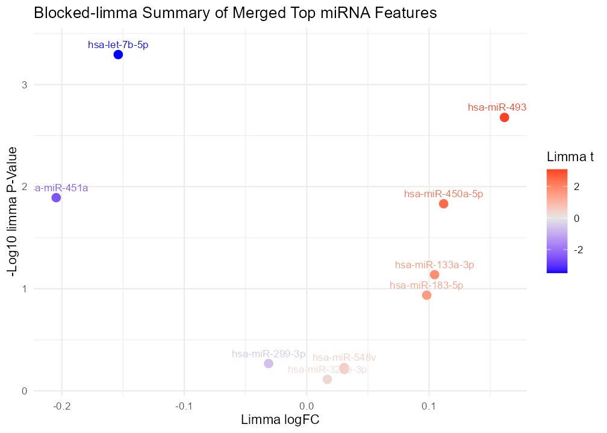

Report runtime: 00:09:48 (started 2026-04-23 20:22:48; finished 2026-04-23 20:32:36).